# Estimating species interactions

SOE 592 – Intro to Time Series Analysis

4 Jan 2024

# Introduction

There are numerous ways to estimate the strength of ecological interactions among members of a food web, including top-down, bottom-up, and competitive interactions. These methods include experimental manipulation, stable isotope analysis, bioenergetics, and observational studies Back in the 1990s, a group of researchers began working on multivariate time series models that would allow people to estimate interactions among community members based on density (biomass) estimates collected over time. Among the best examples is a 2003 paper by Tony Ives and colleagues, which you can find here.

## State model for species interactions

Earlier we saw that we can use a discrete-time Gompertz model to estimate the intrinsic rate of increase and density-dependent effects on population growth. Here we extend the Gompertz model to a multispecies framework. For 2+ interacting species (taxa), we can write

$$x_{i,t} = u_i + \sum^{m}_{j = 1}{b_{i,j} x_{j,t}} + w_t$$

where $u_i$ is the intrinsic (density independent) growth rate, $b_{i,j}$ is the effect of the $j^{th}$ species on species $i$, and $b_{i,j}$ with $i = j$ is the density-dependent effect. We can write this model in matrix notation as

$$\mathbf{x}_t = \mathbf{u} + \mathbf{B} \mathbf{x}_{t-1} + \mathbf{w}_t$$

with

$$\mathbf{u} =
\begin{bmatrix}
u_1 \\
u_2 \\
\vdots \\
u_m
\end{bmatrix}
~ ~ ~ ~ ~ ~ ~
\mathbf{B} =
\begin{bmatrix}
b_{1,1} & b_{1,2} & \dots & b_{1,m} \\
b_{2,1} & b_{1,2} & \dots & b_{2,m} \\
\vdots & \vdots & \ddots & \vdots \\
b_{m,1} & b_{m,2} & \dots & b_{m,m}
\end{bmatrix}$$

## Covariate effects

We can easily accommodate the effects of exogenous drivers (covariates) by including two additional terms in the model, such that

$$\mathbf{x}_t = \mathbf{B} \mathbf{x}_{t-1} + \mathbf{u} + \mathbf{C}
\mathbf{c}_{t-k} + \mathbf{w}_t$$

with the lag $k \geq 0$. The $m \times p$ matrix $\mathbf{C}$ contains the effect(s) of each covariate (cols) on each state (rows). The $p \times 1$ column vector $\mathbf{c}_{t-k}$ contains each of the $p$ covariates at time $t - k$.

The effect(s) of covariates can vary by state/process, species, etc, such that these are both possibilites (that could be compared via some information criterion like AICc):

$$\mathbf{C} =
\begin{bmatrix}
C_{1, Temp} & C_{1, Rain} \\
C_{2, Temp} & C_{2, Rain} \\
\vdots & \vdots \\
C_{m, Temp} & C_{m, Rain}
\end{bmatrix}
~~ \text{or} ~~
\mathbf{C} =
\begin{bmatrix}
C_{Temp} & C_{Rain} \\
C_{Temp} & C_{Rain} \\
\vdots & \vdots \\
C_{Temp} & C_{Rain}
\end{bmatrix}$$

with

$$\mathbf{c}_{t-k} =
\begin{bmatrix}
Temp_{t-k} \\
Rain_{t-k}
\end{bmatrix}$$

# Wolves & moose

The population dynamics of wolves and moose on Isle Royale, an island national park located in north-central Lake Superior, make an interesting case study of a two-species predator-prey system. These populations have been studied intensively since 1958 and unlike other populations of gray wolves, the Isle Royale population has a diet composed almost entirely of moose (they eat the occasional beaver). Because Isle Royale is a national park, the moose are not hunted and their only predator is the gray wolf.

We will use the wolf and moose winter census data from Isle Royale to learn how to fit community interaction models to time series data. The long-term January (wolf) and February (moose) population estimates are provided by the Isle Royale Wolf-Moose Project. You can find out more about the organization and the project [here](http://www.isleroyalewolf.org).

## The model

The mathematical form of the process model for the wolf-moose population dynamics is

$$\begin{equation}
\begin{gathered}
\begin{bmatrix}
x_{w}\\x_{m}
\end{bmatrix}_t =
\begin{bmatrix}
b_{w \rightarrow w} & b_{m \rightarrow w} \\
b_{w \rightarrow m} & b_{m \rightarrow m}
\end{bmatrix}
\begin{bmatrix}
x_{w} \\
x_{m}
\end{bmatrix}_{t-1} +
\begin{bmatrix}
u_{w} \\
u_{m}
\end{bmatrix} +
\begin{bmatrix}
w_{w} \\
w_{m}
\end{bmatrix}_t \\
\begin{bmatrix}
w_{w} \\
w_{m}
\end{bmatrix}_t
\sim
\text{MVN}
\begin{pmatrix}
\begin{bmatrix}
0 \\
0
\end{bmatrix},
\begin{bmatrix}
q_{w} & 0 \\
0 & q_{m}
\end{bmatrix}
\end{pmatrix}
\end{gathered}
\end{equation}$$

where $w$ denotes wolf and $m$ denotes moose. $w \rightarrow w$ is the effect of wolf on wolf (density-dependence) and $w \rightarrow m$ is the effect of wolf on moose (predation effect on moose).

## Get the data

The data are available in the {MARSS} package, so we won’t have to download them the project site; we’ll use the years 1960 to 2011.

**Task:** Get the data and plot the time series.

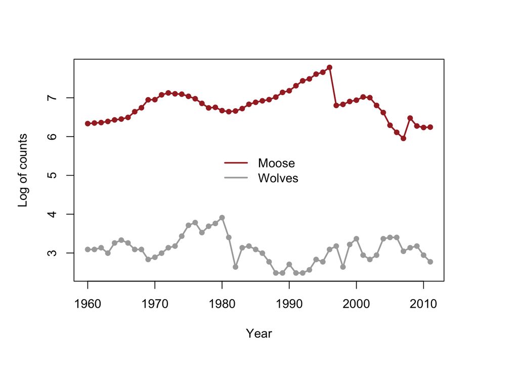

```r
## load MARSS library
library(MARSS)

## set the years
yr_set <- seq(1960, 2011)

## select the wolf & moose data & log-transform them
royale_data <- isleRoyal[isleRoyal[,"Year"] %in% yr_set,
                         c("Wolf", "Moose")] |>
  log()

## set of years
tt <- isleRoyal[, "Year"]

## plot the data
par(mai = c(1.2, 1, 0.3, 0),
    omi = c(0, 0, 0.5, 1))
matplot(yr_set, royale_data,
  type = "o", pch = 16, lwd = 2, lty = "solid",
  col = c("darkgray", "brown"),
  ylab = "Log of counts", xlab = "Year"
)
## add a legend
legend(x = "center", legend = c("Moose", "Wolves"),
       col = c("brown", "darkgray"),lwd = 2, bty = "n")
```

## Fit the model

Fitting our species interaction model with `MARSS()` is similar to how we’ve done it for other problems. The key is to set up the model list correctly and everything should work. Thus, we need to explicitly specify the forms for *all* of the vectors and matrices in the full MARSS model given by

$$\mathbf{x}_t = \mathbf{B} \mathbf{x}_{t-1} + \mathbf{u} + \mathbf{C}
\mathbf{c}_{t-k} + \mathbf{w}_t \\
\mathbf{y}_t = \mathbf{Z} \mathbf{x}_t + \mathbf{a} + \mathbf{D}
\mathbf{d}_{t-h}+ \mathbf{v}_t \\$$

Thus, to fit our species interaction model, we need to set the following:

$$\begin{align}
\mathbf{C} &=
\begin{bmatrix}
0 \\ 0
\end{bmatrix} \\
\mathbf{c}_{t-k} &=
\begin{bmatrix}
0
\end{bmatrix} \\
\mathbf{Z} &=
\begin{bmatrix}
1 & 0 \\ 0 & 1
\end{bmatrix} \\
\mathbf{a} &=
\begin{bmatrix}
0 \\ 0
\end{bmatrix} \\
\mathbf{D} &=
\begin{bmatrix}
0 \\ 0
\end{bmatrix} \\
\mathbf{d}_{t-h} &=
\begin{bmatrix}
0
\end{bmatrix}
\end{align}$$

**Task:** Set up the model list for `MARSS()` (the code below uses textual shortcuts).

```r
## create model list for MARSS()
mod_list <- list(
  ## state model
  B = "unconstrained",
  U = "unequal",
  C = "zero",
  c = "zero",
  Q = "diagonal and unequal",
  ## obs model
  Z = "identity",
  A = "zero",
  D = "zero",
  d = "zero",
  R = "diagonal and unequal"
  )
```

**Task:** Fit the species interaction model define above with `MARSS()`.

```r
## transform the data for MARSS()
royale_data <- t(royale_data)

## fit the model
mod_first <- MARSS(royale_data, model = mod_list)
```

```
## Warning! Reached maxit before parameters converged. Maxit was 500.
##  neither abstol nor log-log convergence tests were passed.
##
## MARSS fit is
## Estimation method: kem
## Convergence test: conv.test.slope.tol = 0.5, abstol = 0.001
## WARNING: maxit reached at  500  iter before convergence.
##  Neither abstol nor log-log convergence test were passed.
##  The likelihood and params are not at the MLE values.
##  Try setting control$maxit higher.
## Log-likelihood: 19.71298
## AIC: -15.42596   AICc: -11.99739
##
##                      Estimate
## R.(Wolf,Wolf)        0.001134
## R.(Moose,Moose)      0.000931
## B.(1,1)              0.784621
## B.(2,1)             -0.134365
## B.(1,2)              0.080977
## B.(2,2)              0.915652
## U.X.Wolf             0.107905
## U.X.Moose            0.988536
## Q.(X.Wolf,X.Wolf)    0.052968
## Q.(X.Moose,X.Moose)  0.027705
## x0.X.Wolf            3.152853
## x0.X.Moose           6.301036
## Initial states (x0) defined at t=0
##
## Standard errors have not been calculated.
## Use MARSSparamCIs to compute CIs and bias estimates.
##
## Convergence warnings
##  Warning: the  R.(Wolf,Wolf)  parameter value has not converged.
##  Warning: the  U.X.Wolf  parameter value has not converged.
##  Warning: the  U.X.Moose  parameter value has not converged.
##  Warning: the  logLik  parameter value has not converged.
##  Type MARSSinfo("convergence") for more info on this warning.
```

**Note:** This model has not converged because we’re trying to estimate both $\mathbf{B}$ and $\mathbf{u}$, which are highly confounded.

## A note on $\mathbf{u}$

Recall that when we discussed univariate state-space models, we saw that it’s *very* difficult to estimate both $\mathbf{u}$ and $\mathbf{B}$. Thus, we can assume the populations are stationay about the mean and subtract the mean from each time series. We can then assume $\mathbf{u}$ = 0.

**Task:** Use the `zscore()` function from the {MARSS} package to remove the mean and also standardize the variance.

```r
## z-score the data
royale_data_z <- zscore(royale_data)
```

**Task:** Update the model list for `MARSS()` by setting $\mathbf{u}$ to **0** and then refit the model.

```r
## set u vector to all 0's
mod_list$U <- "zero"

## refit model
mod_second <- MARSS(royale_data_z, model = mod_list) #, control = cntl.list)
```

```
## Warning! Abstol convergence only. Maxit (=500) reached before log-log convergence.
##
## MARSS fit is
## Estimation method: kem
## Convergence test: conv.test.slope.tol = 0.5, abstol = 0.001
## WARNING: Abstol convergence only no log-log convergence.
##  maxit (=500) reached before log-log convergence.
##  The likelihood and params might not be at the ML values.
##  Try setting control$maxit higher.
## Log-likelihood: -81.60059
## AIC: 183.2012   AICc: 185.5668
##
##                     Estimate
## R.(Wolf,Wolf)         0.0104
## R.(Moose,Moose)       0.0032
## B.(1,1)               0.7742
## B.(2,1)              -0.1799
## B.(1,2)               0.0783
## B.(2,2)               0.8299
## Q.(X.Wolf,X.Wolf)     0.4338
## Q.(X.Moose,X.Moose)   0.1706
## x0.X.Wolf             0.1501
## x0.X.Moose           -1.4072
## Initial states (x0) defined at t=0
##
## Standard errors have not been calculated.
## Use MARSSparamCIs to compute CIs and bias estimates.
##
## Convergence warnings
##  Warning: the  R.(Wolf,Wolf)  parameter value has not converged.
##  Warning: the  R.(Moose,Moose)  parameter value has not converged.
##  Type MARSSinfo("convergence") for more info on this warning.
```

**Note:** This model is still not converging, but this time it looks like the terms in $\mathbf{R}$ for the variances of the observation errors are heading toward 0.

**Task:** Go back and inspect the plot of the log-counts for moose and wolves. Does it look smooth like a random walk or choppy like white noise?

**Task:** Set $\mathbf{R}$ equal to **0** in the model list and refit the model.

```r
## set the observation variance to 0
mod_list$R <- "zero"

## refit the model
mod_third <- MARSS(royale_data_z, model = mod_list)
```

```
## Success! abstol and log-log tests passed at 16 iterations.
## Alert: conv.test.slope.tol is 0.5.
## Test with smaller values (<0.1) to ensure convergence.
##
## MARSS fit is
## Estimation method: kem
## Convergence test: conv.test.slope.tol = 0.5, abstol = 0.001
## Estimation converged in 16 iterations.
## Log-likelihood: -81.53121
## AIC: 179.0624   AICc: 180.5782
##
##                     Estimate
## B.(1,1)               0.7670
## B.(2,1)              -0.1788
## B.(1,2)               0.0783
## B.(2,2)               0.8277
## Q.(X.Wolf,X.Wolf)     0.4485
## Q.(X.Moose,X.Moose)   0.1758
## x0.X.Wolf             0.1471
## x0.X.Moose           -1.4089
## Initial states (x0) defined at t=0
##
## Standard errors have not been calculated.
## Use MARSSparamCIs to compute CIs and bias estimates.
```

## Examine the interaction effects

Recall that the matrix $\mathbf{B}$ contains the intra-specific effects (density-dependence) along its diagonal and the inter-specific effects in the off-diagonals.

**Tip:** We can use the `coef()` function to extract the elements of $\mathbf{B}$ from the `MARSS()` fitted object.

**Task:** Use `coef()` to extract the elements of $\mathbf{B}$.

```r
## get the B matrix
B_hat <- coef(mod_third, type = "matrix")$B

## add some nicer names
rownames(B_hat) <- colnames(B_hat) <- rownames(royale_data)

## inspect the values
print(B_hat, digits = 2)
```

```
##        Wolf Moose
## Wolf   0.77 0.078
## Moose -0.18 0.828
```

## Adding covariates

As we’ve seen before, adding meaningful covariates to the process or observation models can help to better explain temporal patterns in the data. In a forecasting context, covariates can also provide a means for predicting the future response of a state. However, there should be good rationale for including them in any model because you’ll have to explain *why* they’re good at explaining the current state or predicting future states.

In the current case, moose numbers are strongly affected by environmental conditions during the winter and summer. The Isle Royale data set provided with MARSS has climate data from stations in northeastern Minnesota, not far from Isle Royale. The covariate data include the average temperature and precipitation from January-February, July-September, and April-May. The dataset also include three-year running means of these data, where the number for year $t$ is the average of years $t-1$, $t$ and $t+1$ (akin to the linear filter we saw at the beginning of class).

## Update model form

Let’s update our model for community interactions to include the effects of covariates. In this case, we only want the environment to affect moose and not wolves, so our new process model is given by

$$\begin{equation}
\begin{gathered}
\begin{bmatrix}
x_{w} \\
x_{m}
\end{bmatrix}_t =
\begin{bmatrix}
b_{w \rightarrow w} & b_{m \rightarrow w} \\
b_{w \rightarrow m} & b_{m \rightarrow m}
\end{bmatrix}
\begin{bmatrix}
x_{w} \\
x_{m}
\end{bmatrix}_{t-1} +
\begin{bmatrix}
0 & 0 & 0 \\
C_{WT \rightarrow m} & C_{WP \rightarrow m} & C_{ST
\rightarrow m}
\end{bmatrix}
\begin{bmatrix}
c_{WT} \\
c_{WP} \\
c_{ST}
\end{bmatrix}_{t-1} +
\begin{bmatrix}
w_{w} \\
w_{m}
\end{bmatrix}_t
\end{gathered}
\end{equation}$$

where $WT$ is winter temperature, $WP$ is winter precipitation (snow), and $ST$ is summer temperature.

**Task:** Prepare the covariate data by selecting the winter temperature and precipitation data, and the summer temperature.

**Tip:** We need to use the previous year’s climate data with this winter’s abundance data, so the covariates will run from 1959 through 2010.

```r
## names of climatic covariates
covar_names <- c("jan.feb.ave.temp", "jan.feb.ave.precip", "july.sept.ave.temp")

## set the years for the covariates
yr_covars <- seq(1959, 2010)

## select the appropriate covariates
covars <- isleRoyal[isleRoyal[,"Year"] %in% yr_covars, covar_names]

## transpose the covariates & z-score for MARSS()
covars_z <- t(covars) |> zscore()

## rename covariates to match model
rownames(covars_z) <- c("WT", "WP", "ST")
```

### Multicolinearity

Just as with ordinary regression analysis, including two or more covariates that are highly correlated in the same model leads to so-called *multicolineairty*. In these cases, some of the variance in the data will be attributed incorrectly to some of the covariates and give incorrect estimates of the effect size(s).

**Tip:** We can use the code below to estimate and plot the correlation among the covariates.

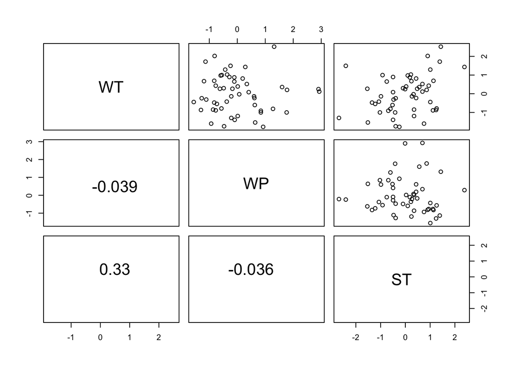

```r
## function to estimate correlation
cor_fun <- function(x, y) {
  text(0.5, 0.5, format(cor(x, y), digits = 2), cex = 2)
}

## pair plots & associated correlations
pairs(t(covars_z), lower.panel = cor_fun)
```

A plot of the covariate data against each other indicates that there is not much correlation between winter temperature and precipitation, which is good for analysis purposes, but warm winters are somewhat correlated with warm summers. The latter will make it harder to interpret the effect of winter versus summer temperature, although the correlation is not too strong.

## Update model definition

Before we can estimate the effects of the environmental covariates on moose, we need to update our model definition for `MARSS()`. We’ll give the elements in $\mathbf{C}$ descriptive names so we can easily identify their values in the `MARSS()` output.

**Task:** Update the model list for `MARSS()`. Note the use of a `list` for the definition of $\mathbf{C}$.

```r
## create model list for MARSS()
mod_list <- list(
  ## state model
  B = "unconstrained",
  U = "unequal",
  C = matrix(list(  0,    0,    0,
                  "WT", "WP", "ST"),
    nrow = 2, ncol = 3, byrow = TRUE),
  c = covars_z,
  Q = "diagonal and unequal",
  ## obs model
  Z = "identity",
  A = "zero",
  D = "zero",
  d = "zero",
  R = "zero"
  )
```

**Task:** Fit the updated model with `MARSS()`.

```r
## fit the model
mod_fourth <- MARSS(royale_data_z, model = mod_list)
```

```
## Success! algorithm run for 15 iterations. abstol and log-log tests passed.
## Alert: conv.test.slope.tol is 0.5.
## Test with smaller values (<0.1) to ensure convergence.
##
## MARSS fit is
## Estimation method: kem
## Convergence test: conv.test.slope.tol = 0.5, abstol = 0.001
## Algorithm ran 15 (=minit) iterations and convergence was reached.
## Log-likelihood: -80.63604
## AIC: 187.2721   AICc: 191.3165
##
##                     Estimate
## B.(1,1)              0.76755
## B.(2,1)             -0.16388
## B.(1,2)              0.07898
## B.(2,2)              0.83374
## U.X.Wolf            -0.01595
## U.X.Moose            0.00378
## Q.(X.Wolf,X.Wolf)    0.44827
## Q.(X.Moose,X.Moose)  0.16999
## x0.X.Wolf            0.17236
## x0.X.Moose          -1.44203
## C.WT                 0.02411
## C.WP                -0.07189
## C.ST                -0.03063
## Initial states (x0) defined at t=0
##
## Standard errors have not been calculated.
## Use MARSSparamCIs to compute CIs and bias estimates.
```

The results suggest what is already known about this system: cold winters and heavy snow are bad for moose, as are hot summers.

# Endnote

Here we’ve examined a relatively simple predator-prey system, but often the system of interest is much more complex and may include 10 or more species. In these cases, care must be given as to how we set up the $mathbf{B}$ matrix with respect to meaningful interactions, such that some elements may need to set to 0 at the outset. Alternatively, we could use a different approach like lasso regression that assumes *a priori* that most of the interactions will be 0 unless the data strongly suggest otherwise (e.g., [Ward et al. 2022](https://peerj.com/articles/14332/)).